# BIOSTAT M280 2016 HW1 Solution Sketch

Dr. Hua Zhou

Jan 21st, 2016

# Q2

Why not test equality with floating point numbers

```r
seven <- .7
two <- .2
one <- .1
```

Surprised?

```r
1 == (seven + two) + one
```

```
## [1] FALSE
```

```r
1 == seven + (two + one)
```

```
## [1] TRUE
```

```r
1 == (seven + one) + two
```

```
## [1] TRUE
```

Now let’s look at the internal representation:

```r
sprintf("%a", c(seven, two, one))       # three numbers
```

```
## [1] "0x1.6666666666666p-1" "0x1.999999999999ap-3" "0x1.999999999999ap-4"
```

- Binary format of 0.7 is $1.0110...0110 \times 2^{-1}$
- Binary format of 0.2 is $1.1001...1010 \times 2^{-3}$ (rounding happens here)
- Binary format of 0.1 is $1.1001...1010 \times 2^{-4}$ (rounding happens here)  
  Recall that R uses the *rounding to even* rule. Let’s take a look at the intemediate numbers when doing (0.7 + 0.2) + 0.1.

```r
sprintf("%a", c(seven + two, one))
```

```
## [1] "0x1.cccccccccccccp-1" "0x1.999999999999ap-4"
```

```r
sprintf("%a", (seven + two) + one)
```

```
## [1] "0x1.fffffffffffffp-1"
```

For the partial sum 0.7 + 0.2, computer (1) aligns the exponent, (2) performs addition, and then (3) normalizes the result. So we get $\begin{eqnarray*} 1.0110...0110 &\times& 2^{-1} \\ + 0.0110...0110 &\times& 2^{-1} \\ = 1.1100...1100 &\times& 2^{-1} \end{eqnarray*}$ Note in the aligning exponent step, we lost the last two digis of 0.2. Next we add the partial sum to 0.1 $\begin{eqnarray*} 1.1100...1100 &\times& 2^{-1} \\ + 0.0011...0011 &\times& 2^{-1} \\ = 1.1111...1111 &\times& 2^{-1} \end{eqnarray*}$ Note again we lost three digits from 0.1 when aligning exponents. The final result is a bit off from 1.

```r
sprintf("%a", 1)
```

```
## [1] "0x1p+0"
```

You may work on the other two orders: 0.7 + (0.2 + 0.1) and (0.7 + 0.1) + 0.2, which lead to exact 1.

```r
sprintf("%a", c(seven, two + one))      # partial sum
```

```
## [1] "0x1.6666666666666p-1" "0x1.3333333333334p-2"
```

```r
sprintf("%a", seven + (two + one))      # why it's not one
```

```
## [1] "0x1p+0"
```

(0.7+0.1)+0.2

```r
sprintf("%a", c(seven + one, two))      # partial sum
```

```
## [1] "0x1.9999999999999p-1" "0x1.999999999999ap-3"
```

```r
sprintf("%a", (seven + one) + two)      # why it's not one
```

```
## [1] "0x1p+0"
```

# Q3

```r
allbut970 <- c(969, 971:1023)
length(allbut970)
```

```
## [1] 54
```

```r
sum(2^allbut970)
```

```
## [1] Inf
```

Reference – this should be biggest number

```r
biggest <- .Machine$double.xmax
biggest
```

```
## [1] 1.797693e+308
```

```r
sprintf("%a", biggest)
```

```
## [1] "0x1.fffffffffffffp+1023"
```

Adding two numbers of dramatically different magnitudes, we get a+b=a! Catastropic cancellation 1.

```r
sum(2^allbut970[-1])
```

```
## [1] 1.797693e+308
```

```r
2^allbut970[1] + sum(2^allbut970[-1])
```

```
## [1] 1.797693e+308
```

Ok, that’s weird enough, what are they internally?

```r
sprintf("%a", sum(2^allbut970[-1]))
```

```
## [1] "0x1.fffffffffffffp+1023"
```

```r
sprintf("%a", sum(2^allbut970[-1]) + 2^allbut970[1])
```

```
## [1] "0x1.fffffffffffffp+1023"
```

Now look at internal view of cumulative sums

```r
c1 <- sprintf("%a", cumsum(2^allbut970[1:53]))
c2 <- sprintf("%a", cumsum(2^allbut970[2:54]))
cbind(c1, c2)
```

```
##       c1                        c2
##  [1,] "0x1p+969"                "0x1p+971"
##  [2,] "0x1.4p+971"              "0x1.8p+972"
##  [3,] "0x1.ap+972"              "0x1.cp+973"
##  [4,] "0x1.dp+973"              "0x1.ep+974"
##  [5,] "0x1.e8p+974"             "0x1.fp+975"
##  [6,] "0x1.f4p+975"             "0x1.f8p+976"
##  [7,] "0x1.fap+976"             "0x1.fcp+977"
##  [8,] "0x1.fdp+977"             "0x1.fep+978"
##  [9,] "0x1.fe8p+978"            "0x1.ffp+979"
## [10,] "0x1.ff4p+979"            "0x1.ff8p+980"
## [11,] "0x1.ffap+980"            "0x1.ffcp+981"
## [12,] "0x1.ffdp+981"            "0x1.ffep+982"
## [13,] "0x1.ffe8p+982"           "0x1.fffp+983"
## [14,] "0x1.fff4p+983"           "0x1.fff8p+984"
```

[output cut: 39 more lines]

# Q4

This is simply the polynomial $y = (x-1)^7$ expanded around $x = 1.0$. $y$ values are very close to 0 when $x$ are close to 1.0. This calculation is taking differences of very close numbers and losing precision (catastropic cancellation 2). The results don’t appear like polynomials due to roundoff errors.

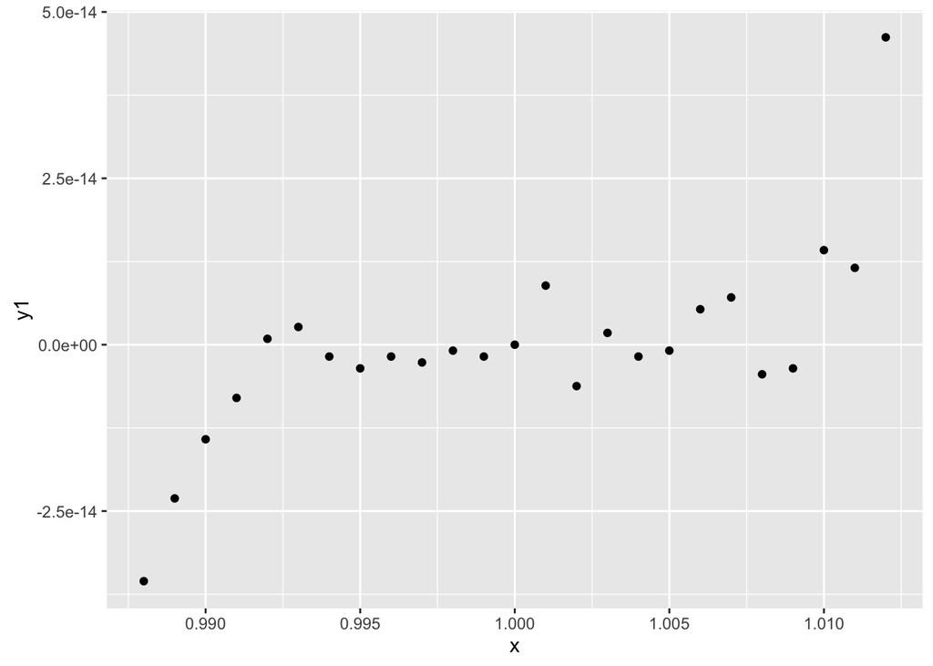

```r
# ggplot2 for nicer graphics
library(ggplot2)
x = seq(from = 0.988, to = 1.012, by = 0.001)
y1 = x^7 - 7 * x^6 + 21 * x^5 - 35 * x^4 + 35 * x^3 - 21 * x^2 + 7 * x - 1
qplot(x, y1)
```

This avoids catastropic cancellation and the result looks much nicer.

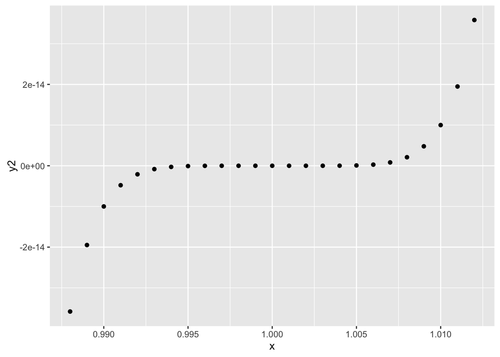

```r
y2 = (x - 1)^7
qplot(x, y2)
```

# Q5

```r
# Let u = ( 1, 2, 3, 3, 2, 1)'
u <- c(1, 2, 3, 3, 2, 1)
# l2 norm squared and coerce it to numeric type
d <- as.numeric(t(u) %*% u)
d
```

```
## [1] 28
```

```r
# another way to compute l2 norm squared
d <- as.numeric(crossprod(u))
d
```

```
## [1] 28
```

```r
# Compute U = I - (2/d) u u' where d = u'u.
U <- diag(6) - (2 / d) * u %*% t(u)
U
```

```
##             [,1]       [,2]       [,3]       [,4]       [,5]        [,6]
## [1,]  0.92857143 -0.1428571 -0.2142857 -0.2142857 -0.1428571 -0.07142857
## [2,] -0.14285714  0.7142857 -0.4285714 -0.4285714 -0.2857143 -0.14285714
## [3,] -0.21428571 -0.4285714  0.3571429 -0.6428571 -0.4285714 -0.21428571
## [4,] -0.21428571 -0.4285714 -0.6428571  0.3571429 -0.4285714 -0.21428571
## [5,] -0.14285714 -0.2857143 -0.4285714 -0.4285714  0.7142857 -0.14285714
## [6,] -0.07142857 -0.1428571 -0.2142857 -0.2142857 -0.1428571  0.92857143
```

```r
# another way (may be faster) to compute outer product
U <- diag(6) - (2 / d) * tcrossprod(u)
U
```

```
##             [,1]       [,2]       [,3]       [,4]       [,5]        [,6]
## [1,]  0.92857143 -0.1428571 -0.2142857 -0.2142857 -0.1428571 -0.07142857
## [2,] -0.14285714  0.7142857 -0.4285714 -0.4285714 -0.2857143 -0.14285714
## [3,] -0.21428571 -0.4285714  0.3571429 -0.6428571 -0.4285714 -0.21428571
## [4,] -0.21428571 -0.4285714 -0.6428571  0.3571429 -0.4285714 -0.21428571
## [5,] -0.14285714 -0.2857143 -0.4285714 -0.4285714  0.7142857 -0.14285714
## [6,] -0.07142857 -0.1428571 -0.2142857 -0.2142857 -0.1428571  0.92857143
```

```r
# yet another way to compute outer product
U <- diag(6) - (2 / d) * outer(u, u)
U
```

```
##             [,1]       [,2]       [,3]       [,4]       [,5]        [,6]
## [1,]  0.92857143 -0.1428571 -0.2142857 -0.2142857 -0.1428571 -0.07142857
## [2,] -0.14285714  0.7142857 -0.4285714 -0.4285714 -0.2857143 -0.14285714
## [3,] -0.21428571 -0.4285714  0.3571429 -0.6428571 -0.4285714 -0.21428571
## [4,] -0.21428571 -0.4285714 -0.6428571  0.3571429 -0.4285714 -0.21428571
## [5,] -0.14285714 -0.2857143 -0.4285714 -0.4285714  0.7142857 -0.14285714
## [6,] -0.07142857 -0.1428571 -0.2142857 -0.2142857 -0.1428571  0.92857143
```

```r
# Let M = U*U
M <- U %*% U
# Find the largest off-diagonal elements of U*U.
max(M[col(M) != row(M)])
```

```
## [1] -2.775558e-17
```

```r
# Find the smallest off-diagonal elements of U*U.
min(M[col(M) != row(M)])
```

```
## [1] -1.491862e-16
```

```r
# two ways to find the largest diagonal elements of U*U
max(diag(M))
```

```
## [1] 1
```

```r
max(M[col(M) == row(M)])
```

```
## [1] 1
```

```r
# two ways to find the smallest diagonal elements of U*U
min(diag(M))
```

```
## [1] 1
```

```r
min(M[col(M) == row(M)])
```

```
## [1] 1
```

```r
# Compute U*u
U %*% u
```

```
##      [,1]
## [1,]   -1
## [2,]   -2
## [3,]   -3
## [4,]   -3
## [5,]   -2
## [6,]   -1
```

```r
# Compute max_j sum_i abs(U(i,j))
max(colSums(abs(U)))
```

```
## [1] 2.285714
```

```r
# Print the third row of U
U[3, ]
```

```
## [1] -0.2142857 -0.4285714  0.3571429 -0.6428571 -0.4285714 -0.2142857
```

```r
# Print the elements of the second column below the diagonal
U[3:6, 2]
```

```
## [1] -0.4285714 -0.4285714 -0.2857143 -0.1428571
```

```r
# Let A be the first three columns of U
A <- U[, 1:3]
# Compute P = AA'
P <- A %*% t(A)
P
```

```
##               [,1]          [,2]          [,3]          [,4]          [,5]
## [1,]  9.285714e-01 -1.428571e-01 -2.142857e-01 -2.775558e-17 -2.775558e-17
## [2,] -1.428571e-01  7.142857e-01 -4.285714e-01 -5.551115e-17 -2.775558e-17
## [3,] -2.142857e-01 -4.285714e-01  3.571429e-01 -2.775558e-17 -5.551115e-17
## [4,] -2.775558e-17 -5.551115e-17 -2.775558e-17  6.428571e-01  4.285714e-01
## [5,] -2.775558e-17 -2.775558e-17 -5.551115e-17  4.285714e-01  2.857143e-01
## [6,] -1.387779e-17 -1.387779e-17 -2.775558e-17  2.142857e-01  1.428571e-01
##               [,6]
## [1,] -1.387779e-17
## [2,] -1.387779e-17
## [3,] -2.775558e-17
## [4,]  2.142857e-01
## [5,]  1.428571e-01
## [6,]  7.142857e-02
```

```r
# another (preferred) way to compute outer product
P <- tcrossprod(A)
P
```

```
##               [,1]          [,2]          [,3]          [,4]          [,5]
## [1,]  9.285714e-01 -1.428571e-01 -2.142857e-01 -2.775558e-17 -2.775558e-17
## [2,] -1.428571e-01  7.142857e-01 -4.285714e-01 -5.551115e-17 -2.775558e-17
## [3,] -2.142857e-01 -4.285714e-01  3.571429e-01 -2.775558e-17 -5.551115e-17
## [4,] -2.775558e-17 -5.551115e-17 -2.775558e-17  6.428571e-01  4.285714e-01
## [5,] -2.775558e-17 -2.775558e-17 -5.551115e-17  4.285714e-01  2.857143e-01
## [6,] -1.387779e-17 -1.387779e-17 -2.775558e-17  2.142857e-01  1.428571e-01
##               [,6]
## [1,] -1.387779e-17
## [2,] -1.387779e-17
## [3,] -2.775558e-17
## [4,]  2.142857e-01
## [5,]  1.428571e-01
## [6,]  7.142857e-02
```

```r
# Compute P*P-P
P %*% P - P
```

```
##               [,1]          [,2]         [,3]          [,4]          [,5]
## [1,]  0.000000e+00  0.000000e+00 0.000000e+00 -1.685160e-17 -3.965082e-18
## [2,]  0.000000e+00  1.110223e-16 0.000000e+00 -1.883414e-17  1.982541e-18
## [3,]  0.000000e+00  0.000000e+00 0.000000e+00  1.232595e-32  2.180795e-17
## [4,] -1.685160e-17 -1.883414e-17 1.232595e-32 -1.110223e-16 -5.551115e-17
## [5,] -3.965082e-18  1.982541e-18 2.180795e-17 -5.551115e-17 -5.551115e-17
## [6,] -1.982541e-18  9.912706e-19 1.090398e-17 -2.775558e-17 -2.775558e-17
##               [,6]
## [1,] -1.982541e-18
## [2,]  9.912706e-19
## [3,]  1.090398e-17
## [4,] -2.775558e-17
## [5,] -2.775558e-17
## [6,] -1.387779e-17
```

```r
# Let B be the last three columns of U
B <- U[, 4:6]
# Compute Q = BB'
Q <- B %*% t(B)
Q
```

```
##               [,1]          [,2]          [,3]          [,4]          [,5]
## [1,]  7.142857e-02  1.428571e-01  2.142857e-01 -2.602085e-17 -1.214306e-17
## [2,]  1.428571e-01  2.857143e-01  4.285714e-01 -5.204170e-17 -2.428613e-17
## [3,]  2.142857e-01  4.285714e-01  6.428571e-01 -2.775558e-17 -3.816392e-17
## [4,] -2.602085e-17 -5.204170e-17 -2.775558e-17  3.571429e-01 -4.285714e-01
## [5,] -1.214306e-17 -2.428613e-17 -3.816392e-17 -4.285714e-01  7.142857e-01
## [6,] -1.387779e-17 -2.775558e-17 -2.775558e-17 -2.142857e-01 -1.428571e-01
##               [,6]
## [1,] -1.387779e-17
## [2,] -2.775558e-17
## [3,] -2.775558e-17
## [4,] -2.142857e-01
## [5,] -1.428571e-01
## [6,]  9.285714e-01
```

```r
# another way to compute outer product
Q <- tcrossprod(B)
Q
```

```
##               [,1]          [,2]          [,3]          [,4]          [,5]
## [1,]  7.142857e-02  1.428571e-01  2.142857e-01 -2.602085e-17 -1.214306e-17
## [2,]  1.428571e-01  2.857143e-01  4.285714e-01 -5.204170e-17 -2.428613e-17
## [3,]  2.142857e-01  4.285714e-01  6.428571e-01 -2.775558e-17 -3.816392e-17
## [4,] -2.602085e-17 -5.204170e-17 -2.775558e-17  3.571429e-01 -4.285714e-01
## [5,] -1.214306e-17 -2.428613e-17 -3.816392e-17 -4.285714e-01  7.142857e-01
## [6,] -1.387779e-17 -2.775558e-17 -2.775558e-17 -2.142857e-01 -1.428571e-01
##               [,6]
## [1,] -1.387779e-17
## [2,] -2.775558e-17
## [3,] -2.775558e-17
## [4,] -2.142857e-01
## [5,] -1.428571e-01
## [6,]  9.285714e-01
```

```r
# Compute Q*Q-Q
Q %*% Q - Q
```

```
##               [,1]          [,2]          [,3]          [,4]          [,5]
## [1,] -1.387779e-17 -2.775558e-17 -2.775558e-17  9.664888e-18  4.088991e-18
## [2,] -2.775558e-17 -5.551115e-17 -5.551115e-17  1.932978e-17  8.177982e-18
## [3,] -2.775558e-17 -5.551115e-17 -1.110223e-16 -5.575897e-18 -1.078007e-17
## [4,]  9.664888e-18  1.932978e-17 -5.575897e-18  5.551115e-17 -5.551115e-17
## [5,]  4.088991e-18  8.177982e-18 -1.078007e-17 -5.551115e-17  1.110223e-16
## [6,] -2.602085e-18 -5.204170e-18 -1.932978e-17  0.000000e+00 -2.775558e-17
##               [,6]
## [1,] -2.602085e-18
## [2,] -5.204170e-18
## [3,] -1.932978e-17
## [4,]  0.000000e+00
## [5,] -2.775558e-17
## [6,]  0.000000e+00
```

```r
# Compute P+Q
P + Q
```

```
##               [,1]          [,2]          [,3]          [,4]          [,5]
## [1,]  1.000000e+00 -2.775558e-17 -5.551115e-17 -5.377643e-17 -3.989864e-17
## [2,] -2.775558e-17  1.000000e+00 -1.110223e-16 -1.075529e-16 -5.204170e-17
## [3,] -5.551115e-17 -1.110223e-16  1.000000e+00 -5.551115e-17 -9.367507e-17
## [4,] -5.377643e-17 -1.075529e-16 -5.551115e-17  1.000000e+00 -1.665335e-16
## [5,] -3.989864e-17 -5.204170e-17 -9.367507e-17 -1.665335e-16  1.000000e+00
## [6,] -2.775558e-17 -4.163336e-17 -5.551115e-17 -5.551115e-17 -2.775558e-17
##               [,6]
## [1,] -2.775558e-17
## [2,] -4.163336e-17
## [3,] -5.551115e-17
## [4,] -5.551115e-17
## [5,] -2.775558e-17
## [6,]  1.000000e+00
```

# Q6

```r
# Read in the matrix in the file 'oringp.dat'.
# The columns are flight number, date, number of O-rings, number failed,
# and temperature at launch.
inputFile <-
  "http://hua-zhou.github.io/teaching/biostatm280-2016winter/oringp.dat"
inputData <- read.table(file = inputFile,
                        col.names = c("flightNumber", "date", "numberOrings",
                                      "numberFailed", "tempAtLaunch"))
# Compute the correlation between number of failures and temperature at launch,
# deleting the last, missing observation (the disaster).
cor(inputData$numberFailed[-24], inputData$tempAtLaunch[-24])
```

```
## [1] -0.5613284
```

# Q7

```r
# n=10
n <- 10
# creates a matrix with all 0
B <- matrix(0, n, n)
# Let the n*n matrix A have elements A(i,j)=1/(i+j-1)
A <- 1 / (row(B) + col(B) - 1)
A
```

```
##            [,1]       [,2]       [,3]       [,4]       [,5]       [,6]
##  [1,] 1.0000000 0.50000000 0.33333333 0.25000000 0.20000000 0.16666667
##  [2,] 0.5000000 0.33333333 0.25000000 0.20000000 0.16666667 0.14285714
##  [3,] 0.3333333 0.25000000 0.20000000 0.16666667 0.14285714 0.12500000
##  [4,] 0.2500000 0.20000000 0.16666667 0.14285714 0.12500000 0.11111111
##  [5,] 0.2000000 0.16666667 0.14285714 0.12500000 0.11111111 0.10000000
##  [6,] 0.1666667 0.14285714 0.12500000 0.11111111 0.10000000 0.09090909
##  [7,] 0.1428571 0.12500000 0.11111111 0.10000000 0.09090909 0.08333333
##  [8,] 0.1250000 0.11111111 0.10000000 0.09090909 0.08333333 0.07692308
##  [9,] 0.1111111 0.10000000 0.09090909 0.08333333 0.07692308 0.07142857
## [10,] 0.1000000 0.09090909 0.08333333 0.07692308 0.07142857 0.06666667
##             [,7]       [,8]       [,9]      [,10]
##  [1,] 0.14285714 0.12500000 0.11111111 0.10000000
##  [2,] 0.12500000 0.11111111 0.10000000 0.09090909
##  [3,] 0.11111111 0.10000000 0.09090909 0.08333333
##  [4,] 0.10000000 0.09090909 0.08333333 0.07692308
##  [5,] 0.09090909 0.08333333 0.07692308 0.07142857
##  [6,] 0.08333333 0.07692308 0.07142857 0.06666667
##  [7,] 0.07692308 0.07142857 0.06666667 0.06250000
##  [8,] 0.07142857 0.06666667 0.06250000 0.05882353
##  [9,] 0.06666667 0.06250000 0.05882353 0.05555556
## [10,] 0.06250000 0.05882353 0.05555556 0.05263158
```

```r
# another way to compute A
A <- 1 / (matrix(1:n, n, n) + matrix(1:n, n, n, byrow = T) - 1)
A
```

```
##            [,1]       [,2]       [,3]       [,4]       [,5]       [,6]
##  [1,] 1.0000000 0.50000000 0.33333333 0.25000000 0.20000000 0.16666667
##  [2,] 0.5000000 0.33333333 0.25000000 0.20000000 0.16666667 0.14285714
##  [3,] 0.3333333 0.25000000 0.20000000 0.16666667 0.14285714 0.12500000
##  [4,] 0.2500000 0.20000000 0.16666667 0.14285714 0.12500000 0.11111111
##  [5,] 0.2000000 0.16666667 0.14285714 0.12500000 0.11111111 0.10000000
##  [6,] 0.1666667 0.14285714 0.12500000 0.11111111 0.10000000 0.09090909
##  [7,] 0.1428571 0.12500000 0.11111111 0.10000000 0.09090909 0.08333333
##  [8,] 0.1250000 0.11111111 0.10000000 0.09090909 0.08333333 0.07692308
##  [9,] 0.1111111 0.10000000 0.09090909 0.08333333 0.07692308 0.07142857
## [10,] 0.1000000 0.09090909 0.08333333 0.07692308 0.07142857 0.06666667
##             [,7]       [,8]       [,9]      [,10]
##  [1,] 0.14285714 0.12500000 0.11111111 0.10000000
##  [2,] 0.12500000 0.11111111 0.10000000 0.09090909
##  [3,] 0.11111111 0.10000000 0.09090909 0.08333333
##  [4,] 0.10000000 0.09090909 0.08333333 0.07692308
##  [5,] 0.09090909 0.08333333 0.07692308 0.07142857
##  [6,] 0.08333333 0.07692308 0.07142857 0.06666667
##  [7,] 0.07692308 0.07142857 0.06666667 0.06250000
##  [8,] 0.07142857 0.06666667 0.06250000 0.05882353
##  [9,] 0.06666667 0.06250000 0.05882353 0.05555556
## [10,] 0.06250000 0.05882353 0.05555556 0.05263158
```

```r
# yet another way to compute A directly
A <- outer(1:n, 1:n, function(x, y) 1 / (x + y - 1))
A
```

```
##            [,1]       [,2]       [,3]       [,4]       [,5]       [,6]
##  [1,] 1.0000000 0.50000000 0.33333333 0.25000000 0.20000000 0.16666667
##  [2,] 0.5000000 0.33333333 0.25000000 0.20000000 0.16666667 0.14285714
##  [3,] 0.3333333 0.25000000 0.20000000 0.16666667 0.14285714 0.12500000
##  [4,] 0.2500000 0.20000000 0.16666667 0.14285714 0.12500000 0.11111111
##  [5,] 0.2000000 0.16666667 0.14285714 0.12500000 0.11111111 0.10000000
##  [6,] 0.1666667 0.14285714 0.12500000 0.11111111 0.10000000 0.09090909
##  [7,] 0.1428571 0.12500000 0.11111111 0.10000000 0.09090909 0.08333333
##  [8,] 0.1250000 0.11111111 0.10000000 0.09090909 0.08333333 0.07692308
##  [9,] 0.1111111 0.10000000 0.09090909 0.08333333 0.07692308 0.07142857
## [10,] 0.1000000 0.09090909 0.08333333 0.07692308 0.07142857 0.06666667
##             [,7]       [,8]       [,9]      [,10]
##  [1,] 0.14285714 0.12500000 0.11111111 0.10000000
##  [2,] 0.12500000 0.11111111 0.10000000 0.09090909
##  [3,] 0.11111111 0.10000000 0.09090909 0.08333333
##  [4,] 0.10000000 0.09090909 0.08333333 0.07692308
##  [5,] 0.09090909 0.08333333 0.07692308 0.07142857
##  [6,] 0.08333333 0.07692308 0.07142857 0.06666667
##  [7,] 0.07692308 0.07142857 0.06666667 0.06250000
##  [8,] 0.07142857 0.06666667 0.06250000 0.05882353
##  [9,] 0.06666667 0.06250000 0.05882353 0.05555556
## [10,] 0.06250000 0.05882353 0.05555556 0.05263158
```

```r
# Compute and print Cholesky factor of A for n=10
R <- chol(A)
R
```

```
##       [,1]      [,2]      [,3]       [,4]        [,5]        [,6]
##  [1,]    1 0.5000000 0.3333333 0.25000000 0.200000000 0.166666667
##  [2,]    0 0.2886751 0.2886751 0.25980762 0.230940108 0.206196525
##  [3,]    0 0.0000000 0.0745356 0.11180340 0.127775313 0.133099284
##  [4,]    0 0.0000000 0.0000000 0.01889822 0.037796447 0.052495066
##  [5,]    0 0.0000000 0.0000000 0.00000000 0.004761905 0.011904762
##  [6,]    0 0.0000000 0.0000000 0.00000000 0.000000000 0.001196474
##  [7,]    0 0.0000000 0.0000000 0.00000000 0.000000000 0.000000000
##  [8,]    0 0.0000000 0.0000000 0.00000000 0.000000000 0.000000000
##  [9,]    0 0.0000000 0.0000000 0.00000000 0.000000000 0.000000000
## [10,]    0 0.0000000 0.0000000 0.00000000 0.000000000 0.000000000
##               [,7]         [,8]         [,9]        [,10]
##  [1,] 0.1428571429 1.250000e-01 1.111111e-01 1.000000e-01
##  [2,] 0.1855768722 1.683938e-01 1.539601e-01 1.417132e-01
##  [3,] 0.1330992844 1.304373e-01 1.264847e-01 1.219673e-01
##  [4,] 0.0629940788 7.015250e-02 7.482933e-02 7.770738e-02
##  [5,] 0.0194805195 2.651515e-02 3.263403e-02 3.776224e-02
##  [6,] 0.0035894208 6.764678e-03 1.030808e-02 1.391591e-02
##  [7,] 0.0003001624 1.050569e-03 2.241213e-03 3.782047e-03
##  [8,] 0.0000000000 7.523277e-05 3.009311e-04 7.169241e-04
##  [9,] 0.0000000000 0.000000e+00 1.884502e-05 8.480261e-05
## [10,] 0.0000000000 0.000000e+00 0.000000e+00 4.718564e-06
```

```r
# n=20
n <- 20
A <- outer(1:n, 1:n, function(x, y) 1 / (x + y - 1))
A
```

```
##             [,1]       [,2]       [,3]       [,4]       [,5]       [,6]
##  [1,] 1.00000000 0.50000000 0.33333333 0.25000000 0.20000000 0.16666667
##  [2,] 0.50000000 0.33333333 0.25000000 0.20000000 0.16666667 0.14285714
##  [3,] 0.33333333 0.25000000 0.20000000 0.16666667 0.14285714 0.12500000
##  [4,] 0.25000000 0.20000000 0.16666667 0.14285714 0.12500000 0.11111111
##  [5,] 0.20000000 0.16666667 0.14285714 0.12500000 0.11111111 0.10000000
##  [6,] 0.16666667 0.14285714 0.12500000 0.11111111 0.10000000 0.09090909
##  [7,] 0.14285714 0.12500000 0.11111111 0.10000000 0.09090909 0.08333333
##  [8,] 0.12500000 0.11111111 0.10000000 0.09090909 0.08333333 0.07692308
##  [9,] 0.11111111 0.10000000 0.09090909 0.08333333 0.07692308 0.07142857
## [10,] 0.10000000 0.09090909 0.08333333 0.07692308 0.07142857 0.06666667
## [11,] 0.09090909 0.08333333 0.07692308 0.07142857 0.06666667 0.06250000
## [12,] 0.08333333 0.07692308 0.07142857 0.06666667 0.06250000 0.05882353
## [13,] 0.07692308 0.07142857 0.06666667 0.06250000 0.05882353 0.05555556
## [14,] 0.07142857 0.06666667 0.06250000 0.05882353 0.05555556 0.05263158
```

[output cut: 69 more lines]

```r
# Compute and print Cholesky factor of A for n=20
R <- try(chol(A))
if (class(R) == "try-error") {
  cat("Caught an error for Cholesky decomposision")
  detA <- det(A)
} else {
  detA <- prod(diag(R))^2
}
```

```
## Caught an error for Cholesky decomposision
```

```r
detA
```

```
## [1] -1.100433e-195
```

```r
rm(list = ls())
```